# General analysis of tank data in World of Tanks

## What's this and how was it obtained?

This is an analysis of some data about tanks in World of Tanks. The data was obtained using the Wargaming.net Public API on March 2021, for patch 1.2, and was extracted by calling the method [vehicles](https://developers.wargaming.net/reference/all/wot/encyclopedia/vehicles/) to obtain all vehicles with their list of modules, and then [vehicle profile](https://developers.wargaming.net/reference/all/wot/encyclopedia/vehicleprofile) to obtain data about each configuration. A subset of the information obtained was saved as a CSV file that you can find [here](https://github.com/GuilleHoardings/wot_tank_data/blob/main/wot_data.csv).

I wanted to have the information in CSV format to be able to play with it in a spreadsheet, but I quickly found that it was too much information: there are many tanks and many configurations. That's why in the end I decided to analyze it using Python (with Matplotlib, Pandas and Seaborn). Pull requests and tips for improving the code are appreciated: I know there has to be a better way... Probably, there are even errors! You can find the code [in this Github repository](https://github.com/GuilleHoardings/wot_tank_data/).

What's the goal of all of this? Nothing in particular: just trying to visualize the data about the tanks and answer some questions that pique my curiosity.

# Tanks per tier, class and nation

First question: how many tanks are there? Let's start by reading the CSV file, which has one line per tank configuration.

Wow! There are 685 tanks in 14522 configurations, so the average number of configurations per tank is 21.2. That's a lot of variety, but you have to take into account that when you have three radios, for instance, you are multiplying your configurations by 3 without changing the play style of the tank.  
However, an interesting question is: are the configurations distributed uniformly or are there tanks with many more configurations than others? Let's plot a histogram.

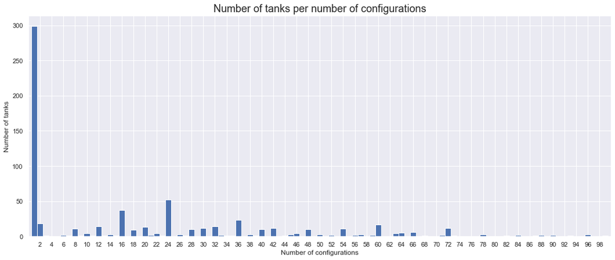

So almost 300 tanks only have one configuration: they are probably premium and tier 10 tanks. We will check that later.

The next most probable value is 24 configurations, and there are even around 25 tanks with 36 configurations. But the previous histogram was cut in order to be able to distinguish the bins. Which are the tanks with more configurations? Let's see:

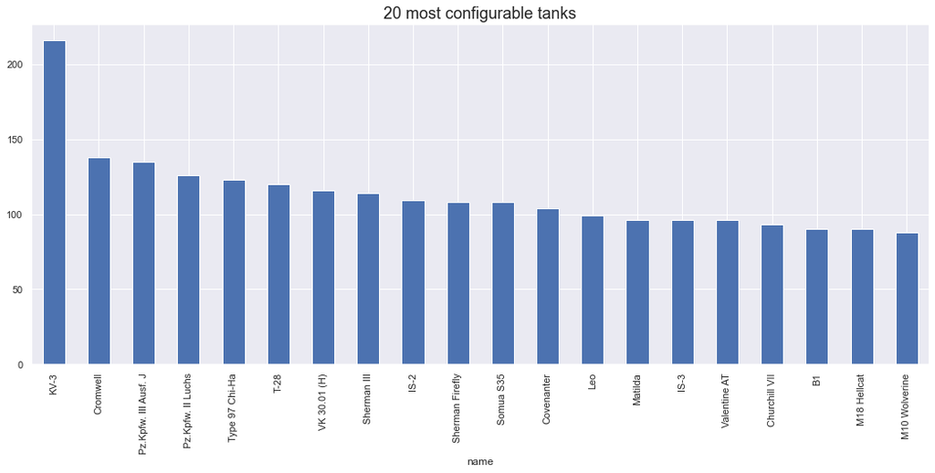

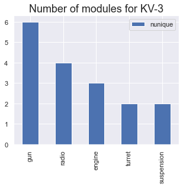

Six guns and four radios. Not bad, not bad...

Previously I guessed that there were so many tanks with only one configuration because they were tier 10 or premiums. Let's check the distribution of number of configurations per tier:

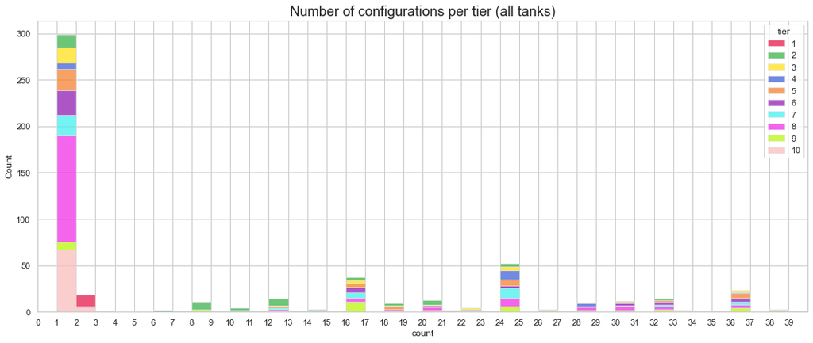

In the first column on the left, we can see that there are around 70 tier 10 tanks with only one configuration, but there are even more tier 8 tanks with one configuration. In addition, we can see around 20 tanks with only two configurations and they are either tier 1 or tier 10.

Another way to visualize this is plotting the number of occurrences of each number of configurations with a different color for each tier:

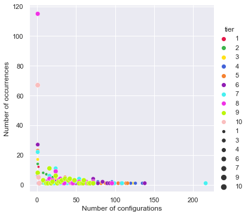

Seeing that the points are lighter on the right side, we can deduce that higher number of configurations are more usual with lower tiers.

Let's plot the histogram only for non-premium tanks:

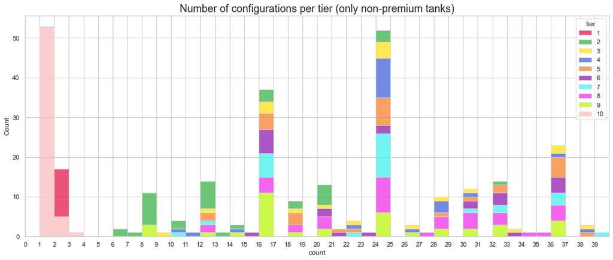

We can see that all non-premium tanks with only one configuration are tier 10. But there are almost 300 tanks with only one configuration and now that we are plotting only non-premiums we only have a little more than 50... So, how many premium tanks are there?

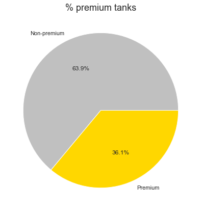

Let's plot them by tier:

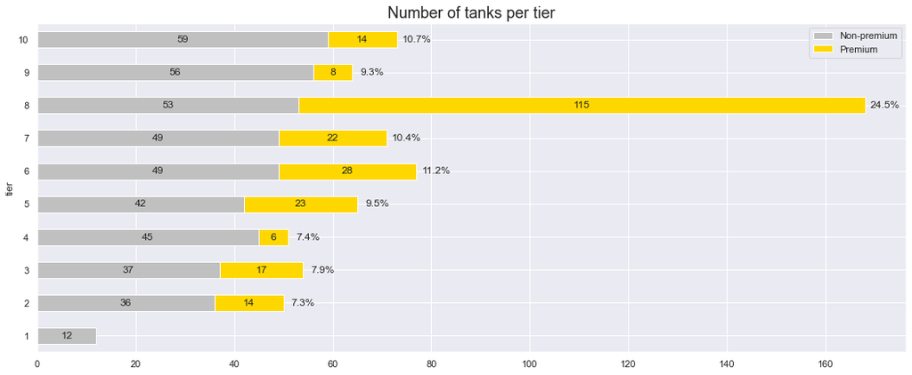

Things we can see:

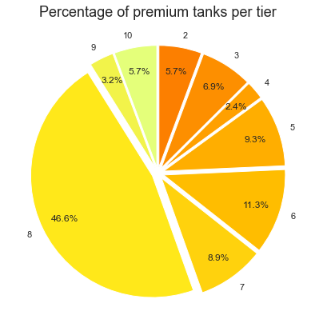

What about the distribution of tanks per nation and class?

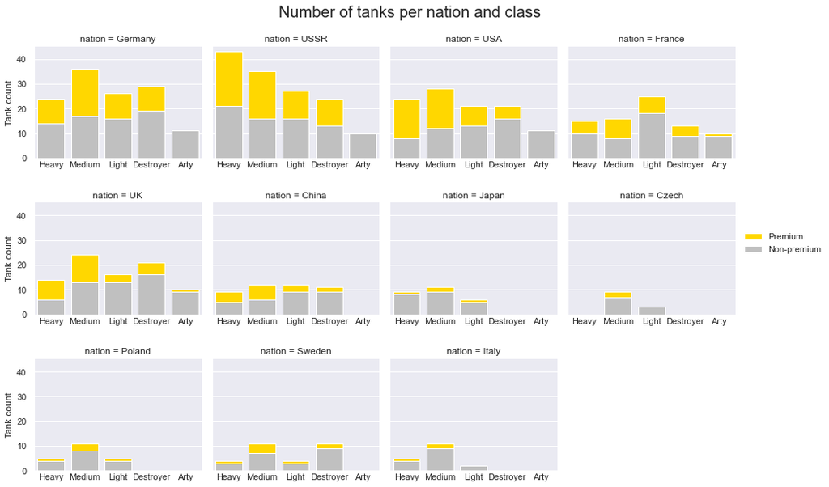

There are some apparent patterns:

- Germany and UK: focused on mediums and tank destroyers.
- USSR: focused on heavy tanks, although it is the nation with more tanks and the number of mediums (second class for USSR) is similar to number of mediums in Germany (first class for Germany).
- USA: quite balanced, with a little more mediums.
- France: focused on light tanks. Wheeled vehicles is probably the cause.
- Chine: quite balanced, with less heavy tanks.
- Tank destroyers and arties are usually not present in the nations most-recently added, except for Sweden, that has a tank destroyer line.

And what about the number of tanks per class independently of nation?

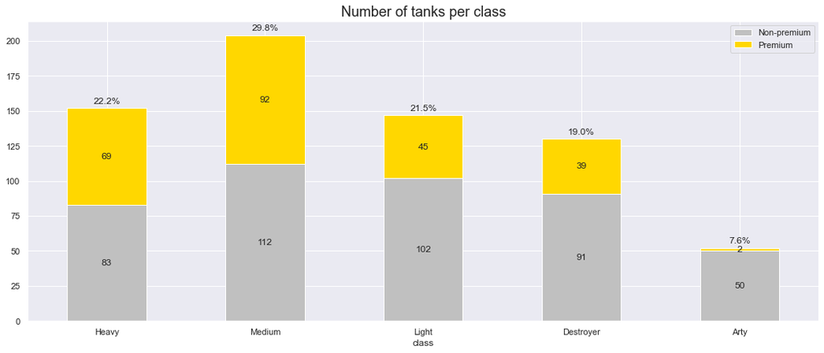

There are more than 200 mediums and around 150 heavies and lights. Tank destroyers lag behind at about 125, while there are only around 50 arties. The figure also shows that heavies and mediums are more balanced between premium and not-premium than the rest of the classes.

Let's see how many tanks each nation has...

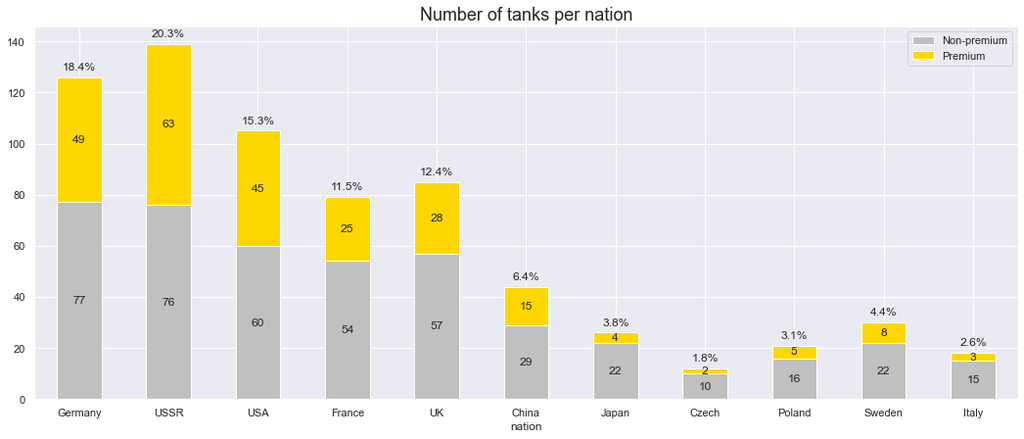

Although I was under the impression that the first five nations had a similar number of tanks, USSR has almost twice the number of tanks of France.

It's also apparent that there are nations (USSR, Germany, USA) where the number of premiums is much closer to non-premiums than in others.

Well, that's it for now. Many more analysis could be done, but this has already taken many, many hours to create... and I want to play!